# Graduation_outcome

- id:"qk7d-gecv"
- name:"2005 - 2015 Graduation Outcomes"
- assetType:"dataset"
- attribution:"Department of Education (DOE)"
- averageRating:0
- category:"Education"
- createdAt:1457473988.

you can find the data set here [links][https://catalog.data.gov/dataset/regents-exam-results]

**Description:**  
Graduation results for all students by year; cohorts of 2001 through 2011 (Classes of 2005 through 2015).  
Graduation Outcomes as Calculated by the New York State Education Department.  
The New York State calculation method was first adopted for the Cohort of 2001 (Class of 2005). The cohort consists of all students who first entered 9th grade in a given school year (e.g., the Cohort of 2006 entered 9th grade in the 2006-2007 school year).  
Graduates are defined as those students earning either a Local or Regents diploma and exclude those earning either a special education (IEP) diploma or GED.  
In order to comply with FERPA regulations on public reporting of education outcomes, rows with a cohort of 20 or fewer students are suppressed.  
Due to the small number of students identified as Native American or Multi-Racial, these ethnicities are not reported on the Ethnicity tab; however, these students are included in the counts on all other tabs.  
4 Year August outcomes are available for the 2004-2011 cohorts at the citywide level and for the 2005-2011 cohorts at the borough, district and school level. 5 Year August outcomes are available for the 2006-2010 cohorts. Cells are blank when data is not available.  
Charter schools are not included in the NYSED calculation of graduation rates for NYC.  
School level results are not presented for District 79 and District 75 schools, but their outcomes are included in citywide totals.  
Starting with the 2009 cohort (Class of 2013), students with IEPs could use the compensatory score option (CSO) to meet graduation requirements, which contributed to an increase in the graduation rate.  
Students are considered English Language Learners by NY State if classified as an ELL as of graduation.

```python
import pandas as pd
import numpy as np
import matplotlib.pyplot as plt
import seaborn as sns
import json
import cufflinks as cf
from plotly.offline import download_plotlyjs,init_notebook_mode,plot,iplot
init_notebook_mode(connected=True)
cf.go_offline()
```

```python
data = json.load(open("2005_-_2015_Graduation_Outcomes.json"))
```

```python
df_meta = pd.DataFrame(data["meta"]["view"]["columns"]) # 245938028
df_meta.head(20)
```

|  | id | name | dataTypeName | fieldName | position | renderTypeName | format | flags | tableColumnId | width | cachedContents |
| --- | --- | --- | --- | --- | --- | --- | --- | --- | --- | --- | --- |
| 0 | -1 | sid | meta_data | :sid | 0 | meta_data | {} | [hidden] | NaN | NaN | NaN |
| 1 | -1 | id | meta_data | :id | 0 | meta_data | {} | [hidden] | NaN | NaN | NaN |
| 2 | -1 | position | meta_data | :position | 0 | meta_data | {} | [hidden] | NaN | NaN | NaN |
| 3 | -1 | created_at | meta_data | :created_at | 0 | meta_data | {} | [hidden] | NaN | NaN | NaN |
| 4 | -1 | created_meta | meta_data | :created_meta | 0 | meta_data | {} | [hidden] | NaN | NaN | NaN |
| 5 | -1 | updated_at | meta_data | :updated_at | 0 | meta_data | {} | [hidden] | NaN | NaN | NaN |
| 6 | -1 | updated_meta | meta_data | :updated_meta | 0 | meta_data | {} | [hidden] | NaN | NaN | NaN |
| 7 | -1 | meta | meta_data | :meta | 0 | meta_data | {} | [hidden] | NaN | NaN | NaN |
| 8 | 245938027 | Cohort Year | number | cohort_year | 1 | number | {'precisionStyle': 'standard', 'noCommas': 'tr... | NaN | 34866904.0 | 128.0 | {'non_null': 430, 'average': '2006.18604651162... |
| 9 | 245938028 | Cohort Category | text | cohort_category | 2 | text | {} | NaN | 34866905.0 | 174.0 | {'non_null': 430, 'largest': '6 Year', 'null':... |
| 10 | 245938029 | Demographic | text | demographic | 3 | text | {} | NaN | 34866906.0 | 232.0 | {'non_null': 430, 'largest': 'White', 'null': ... |
| 11 | 245938030 | # Total Cohort | number | total_cohort | 4 | number | {} | NaN | 34866907.0 | 175.0 | {'non_null': 430, 'average': '30728.8302325581... |
| 12 | 245938031 | # Total Grads | number | total_grads | 5 | number | {} | NaN | 34866908.0 | 151.0 | {'non_null': 430, 'average': '20082.3023255814... |
| 13 | 245938032 | % of cohort Total Grads | number | of_cohort_total_grads_1 | 6 | number | {'precisionStyle': 'percentage', 'percentScale... | NaN | 34866909.0 | 195.0 | {'non_null': 430, 'average': '62.3197674418604... |
| 14 | 245938033 | # of cohort Total Grads | number | of_cohort_total_grads_2 | 7 | number | {} | NaN | 34866910.0 | 193.0 | {'non_null': 430, 'average': '16250.7488372093... |
| 15 | 245938034 | % of cohort Total Regents | number | of_cohort_total_regents | 8 | number | {'precisionStyle': 'percentage', 'percentScale... | NaN | 34866911.0 | 217.0 | {'non_null': 430, 'average': '49.4825581395348... |
| 16 | 245938035 | % of grads Total Regents | number | of_grads_total_regents_1 | 9 | number | {'precisionStyle': 'percentage', 'percentScale... | NaN | 34866912.0 | 206.0 | {'non_null': 430, 'average': '75.4481395348837... |
| 17 | 245938036 | # of grads Total Regents | number | of_grads_total_regents_2 | 10 | number | {} | NaN | 34866913.0 | 206.0 | {'non_null': 420, 'average': '5002.16904761904... |
| 18 | 245938037 | % of cohort Advanced Regents | number | of_cohort_advanced_regents | 11 | number | {'precisionStyle': 'percentage', 'percentScale... | NaN | 34866914.0 | 170.0 | {'non_null': 420, 'average': '16.5321428571428... |
| 19 | 245938038 | % of grads Advanced Regents | number | of_grads_advanced_regents_1 | 12 | number | {'precisionStyle': 'percentage', 'percentScale... | NaN | 34866915.0 | 187.0 | {'non_null': 420, 'average': '23.7511904761904... |

```python
df_meta.tail(10)
```

|  | id | name | dataTypeName | fieldName | position | renderTypeName | format | flags | tableColumnId | width | cachedContents |
| --- | --- | --- | --- | --- | --- | --- | --- | --- | --- | --- | --- |
| 20 | 245938039 | # of grads Advanced Regents | number | of_grads_advanced_regents_2 | 13 | number | {} | NaN | 34866916.0 | 183.0 | {'non_null': 420, 'average': '11331.4928571428... |
| 21 | 245938040 | % of cohort Regents w/o Advanced | number | of_cohort_regents_w_o_advanced | 14 | number | {'precisionStyle': 'percentage', 'percentScale... | NaN | 34866917.0 | 255.0 | {'non_null': 420, 'average': '33.1673809523809... |
| 22 | 245938041 | % of grads Regents w/o Advanced | number | of_grads_regents_w_o_advanced_1 | 15 | number | {'precisionStyle': 'percentage', 'percentScale... | NaN | 34866918.0 | 243.0 | {'non_null': 420, 'average': '51.9254761904761... |
| 23 | 245938042 | # of grads Regents w/o Advanced | number | of_grads_regents_w_o_advanced_2 | 16 | number | {} | NaN | 34866919.0 | 262.0 | {'non_null': 430, 'average': '3839.4', 'larges... |
| 24 | 245938043 | % of cohort Local | number | of_cohort_local | 17 | number | {'precisionStyle': 'percentage', 'percentScale... | NaN | 34866920.0 | 178.0 | {'non_null': 430, 'average': '12.8602325581395... |
| 25 | 245938044 | % of grads Local | number | of_grads_local | 18 | number | {'precisionStyle': 'percentage', 'percentScale... | NaN | 34866921.0 | 166.0 | {'non_null': 430, 'average': '24.6011627906976... |
| 26 | 245938045 | # Still Enrolled | number | still_enrolled | 19 | number | {} | NaN | 34866922.0 | 160.0 | {'non_null': 430, 'average': '4519.99069767441... |
| 27 | 245938046 | % of cohort Still Enrolled | number | of_cohort_still_enrolled | 20 | number | {'precisionStyle': 'percentage', 'percentScale... | NaN | 34866923.0 | 202.0 | {'non_null': 430, 'average': '15.6209302325581... |
| 28 | 245938047 | # Dropped Out | number | dropped_out | 21 | number | {'precisionStyle': 'standard', 'noCommas': 'fa... | NaN | 34866924.0 | 142.0 | {'non_null': 430, 'average': '5014.17906976744... |
| 29 | 245938048 | % of cohort Dropped Out | number | of_cohort_dropped_out | 22 | number | {'precisionStyle': 'percentage', 'percentScale... | NaN | 34866925.0 | 213.0 | {'non_null': 430, 'average': '17.3837209302325... |

```python
df_meta.info()
```

```
<class 'pandas.core.frame.DataFrame'>
RangeIndex: 30 entries, 0 to 29
Data columns (total 11 columns):
 #   Column          Non-Null Count  Dtype
---  ------          --------------  -----
 0   id              30 non-null     int64
 1   name            30 non-null     object
 2   dataTypeName    30 non-null     object
 3   fieldName       30 non-null     object
 4   position        30 non-null     int64
 5   renderTypeName  30 non-null     object
 6   format          30 non-null     object
 7   flags           8 non-null      object
 8   tableColumnId   22 non-null     float64
 9   width           22 non-null     float64
 10  cachedContents  22 non-null     object
dtypes: float64(2), int64(2), object(7)
memory usage: 2.7+ KB
```

data["meta"]

```python
df_data = pd.DataFrame(data["data"])
df_data.head(10)
```

|  | 0 | 1 | 2 | 3 | 4 | 5 | 6 | 7 | 8 | 9 | ... | 20 | 21 | 22 | 23 | 24 | 25 | 26 | 27 | 28 | 29 |
| --- | --- | --- | --- | --- | --- | --- | --- | --- | --- | --- | --- | --- | --- | --- | --- | --- | --- | --- | --- | --- | --- |
| 0 | row-8ezw_fvpi~9vcu | 00000000-0000-0000-13BA-9C4637CEEB7D | 0 | 1542139135 | None | 1542139135 | None | { } | 2001 | 4 Year June | ... | 677 | 6.40 | 24.30 | 1803 | 17.10 | 64.60 | 3895 | 37.00 | 3220 | 30.60 |
| 1 | row-t2yg.eh7e~sddq | 00000000-0000-0000-CDCB-E0DEDBC2FABC | 0 | 1542139135 | None | 1542139135 | None | { } | 2001 | 5 Year June | ... | 862 | 8.20 | 22.00 | 2701 | 25.60 | 68.90 | 1516 | 14.40 | 4193 | 39.80 |
| 2 | row-izud_8uvm_5mvi | 00000000-0000-0000-8E9D-003AB51D26C4 | 0 | 1542139135 | None | 1542139135 | None | { } | 2001 | 6 Year | ... | 911 | 8.60 | 21.20 | 3028 | 28.70 | 70.50 | 655 | 6.20 | 4598 | 43.60 |
| 3 | row-6d6m.hkrp_u2g4 | 00000000-0000-0000-30F7-6D14D65EAF7C | 0 | 1542139135 | None | 1542139135 | None | { } | 2002 | 4 Year June | ... | 507 | 6.80 | 30.00 | 1062 | 14.20 | 62.80 | 3062 | 41.10 | 2330 | 31.30 |
| 4 | row-ugfs.eggj~p8kf | 00000000-0000-0000-2659-9200A4525471 | 0 | 1542139135 | None | 1542139135 | None | { } | 2002 | 5 Year June | ... | 618 | 8.30 | 26.30 | 1578 | 21.20 | 67.00 | 1457 | 19.50 | 3041 | 40.80 |
| 5 | row-ki35.2fvi~esju | 00000000-0000-0000-ECD0-FBA0DC831614 | 0 | 1542139135 | None | 1542139135 | None | { } | 2002 | 6 Year | ... | 671 | 9.00 | 24.60 | 1891 | 25.40 | 69.30 | 697 | 9.40 | 3356 | 45.00 |
| 6 | row-88dc_bt6p~tmdc | 00000000-0000-0000-FA52-2FC059D4A4EE | 0 | 1542139135 | None | 1542139135 | None | { } | 2003 | 4 Year June | ... | 619 | 7.60 | 30.20 | 1143 | 14.00 | 55.70 | 3360 | 41.20 | 2394 | 29.30 |
| 7 | row-wx6d~iasz_krwi | 00000000-0000-0000-3C34-2F2E77E84515 | 0 | 1542139135 | None | 1542139135 | None | { } | 2003 | 5 Year June | ... | 801 | 9.80 | 25.80 | 1946 | 23.80 | 62.70 | 1327 | 16.30 | 3111 | 38.10 |
| 8 | row-yswx~g7en.p3jm | 00000000-0000-0000-B1AC-0CC480CF66BB | 0 | 1542139135 | None | 1542139135 | None | { } | 2003 | 6 Year | ... | 853 | 10.60 | 25.10 | 2178 | 27.10 | 64.20 | 570 | 7.10 | 3361 | 41.80 |
| 9 | row-p8s2~8xaq.f8tc | 00000000-0000-0000-9F23-93F2C06C8F35 | 0 | 1542139135 | None | 1542139135 | None | { } | 2004 | 4 Year June | ... | 1017 | 12.00 | 33.50 | 1535 | 18.10 | 50.50 | 3288 | 38.70 | 1840 | 21.70 |

10 rows × 30 columns

```python
df_meta.head(20)
```

|  | id | name | dataTypeName | fieldName | position | renderTypeName | format | flags | tableColumnId | width | cachedContents |
| --- | --- | --- | --- | --- | --- | --- | --- | --- | --- | --- | --- |
| 0 | -1 | sid | meta_data | :sid | 0 | meta_data | {} | [hidden] | NaN | NaN | NaN |
| 1 | -1 | id | meta_data | :id | 0 | meta_data | {} | [hidden] | NaN | NaN | NaN |
| 2 | -1 | position | meta_data | :position | 0 | meta_data | {} | [hidden] | NaN | NaN | NaN |
| 3 | -1 | created_at | meta_data | :created_at | 0 | meta_data | {} | [hidden] | NaN | NaN | NaN |
| 4 | -1 | created_meta | meta_data | :created_meta | 0 | meta_data | {} | [hidden] | NaN | NaN | NaN |
| 5 | -1 | updated_at | meta_data | :updated_at | 0 | meta_data | {} | [hidden] | NaN | NaN | NaN |
| 6 | -1 | updated_meta | meta_data | :updated_meta | 0 | meta_data | {} | [hidden] | NaN | NaN | NaN |
| 7 | -1 | meta | meta_data | :meta | 0 | meta_data | {} | [hidden] | NaN | NaN | NaN |
| 8 | 245938027 | Cohort Year | number | cohort_year | 1 | number | {'precisionStyle': 'standard', 'noCommas': 'tr... | NaN | 34866904.0 | 128.0 | {'non_null': 430, 'average': '2006.18604651162... |
| 9 | 245938028 | Cohort Category | text | cohort_category | 2 | text | {} | NaN | 34866905.0 | 174.0 | {'non_null': 430, 'largest': '6 Year', 'null':... |
| 10 | 245938029 | Demographic | text | demographic | 3 | text | {} | NaN | 34866906.0 | 232.0 | {'non_null': 430, 'largest': 'White', 'null': ... |
| 11 | 245938030 | # Total Cohort | number | total_cohort | 4 | number | {} | NaN | 34866907.0 | 175.0 | {'non_null': 430, 'average': '30728.8302325581... |
| 12 | 245938031 | # Total Grads | number | total_grads | 5 | number | {} | NaN | 34866908.0 | 151.0 | {'non_null': 430, 'average': '20082.3023255814... |
| 13 | 245938032 | % of cohort Total Grads | number | of_cohort_total_grads_1 | 6 | number | {'precisionStyle': 'percentage', 'percentScale... | NaN | 34866909.0 | 195.0 | {'non_null': 430, 'average': '62.3197674418604... |
| 14 | 245938033 | # of cohort Total Grads | number | of_cohort_total_grads_2 | 7 | number | {} | NaN | 34866910.0 | 193.0 | {'non_null': 430, 'average': '16250.7488372093... |
| 15 | 245938034 | % of cohort Total Regents | number | of_cohort_total_regents | 8 | number | {'precisionStyle': 'percentage', 'percentScale... | NaN | 34866911.0 | 217.0 | {'non_null': 430, 'average': '49.4825581395348... |
| 16 | 245938035 | % of grads Total Regents | number | of_grads_total_regents_1 | 9 | number | {'precisionStyle': 'percentage', 'percentScale... | NaN | 34866912.0 | 206.0 | {'non_null': 430, 'average': '75.4481395348837... |
| 17 | 245938036 | # of grads Total Regents | number | of_grads_total_regents_2 | 10 | number | {} | NaN | 34866913.0 | 206.0 | {'non_null': 420, 'average': '5002.16904761904... |
| 18 | 245938037 | % of cohort Advanced Regents | number | of_cohort_advanced_regents | 11 | number | {'precisionStyle': 'percentage', 'percentScale... | NaN | 34866914.0 | 170.0 | {'non_null': 420, 'average': '16.5321428571428... |
| 19 | 245938038 | % of grads Advanced Regents | number | of_grads_advanced_regents_1 | 12 | number | {'precisionStyle': 'percentage', 'percentScale... | NaN | 34866915.0 | 187.0 | {'non_null': 420, 'average': '23.7511904761904... |

```python
df_data.columns
```

```
RangeIndex(start=0, stop=30, step=1)
```

```python
df_meta.index
```

```
RangeIndex(start=0, stop=30, step=1)
```

the indexs in the df_meta are the columns in the df_data if you look in the data_meta from row 0 to 7 you will find out this is the name of the columns in the df_data

the columns name in data_meta about information you Demographic should be text and the expected postion 3 (the third columns).

## stepes.

- the data types are not correct
- the columns name are int
- we have alot of columns that has duplicate values
- we have some columns that have bractes and Null values.

## Task:

- removing the columns 0 to 7
- renaming the columns.

```python
df_data.shape
```

```
(430, 30)
```

```python
df_data.info()
```

```
<class 'pandas.core.frame.DataFrame'>
RangeIndex: 430 entries, 0 to 429
Data columns (total 30 columns):
 #   Column  Non-Null Count  Dtype
---  ------  --------------  -----
 0   0       430 non-null    object
 1   1       430 non-null    object
 2   2       430 non-null    int64
 3   3       430 non-null    int64
 4   4       0 non-null      object
 5   5       430 non-null    int64
 6   6       0 non-null      object
 7   7       430 non-null    object
 8   8       430 non-null    object
 9   9       430 non-null    object
```

[output cut: 22 more lines]

```python
copy_df = df_data.copy()
```

```python
copy_df.describe()
```

|  | 2 | 3 | 5 |
| --- | --- | --- | --- |
| count | 430.0 | 4.300000e+02 | 4.300000e+02 |
| mean | 0.0 | 1.542139e+09 | 1.542139e+09 |
| std | 0.0 | 0.000000e+00 | 0.000000e+00 |
| min | 0.0 | 1.542139e+09 | 1.542139e+09 |
| 25% | 0.0 | 1.542139e+09 | 1.542139e+09 |
| 50% | 0.0 | 1.542139e+09 | 1.542139e+09 |
| 75% | 0.0 | 1.542139e+09 | 1.542139e+09 |
| max | 0.0 | 1.542139e+09 | 1.542139e+09 |

```python
copy_df[3].value_counts()
```

```
1542139135    430
Name: 3, dtype: int64
```

```python
copy_df[5].value_counts()
```

```
1542139135    430
Name: 5, dtype: int64
```

```python
copy_df[6].value_counts()
```

```
Series([], Name: 6, dtype: int64)
```

```python
copy_df[7].value_counts()
```

```
{ }    430
Name: 7, dtype: int64
```

```python
copy_df.info()
```

```
<class 'pandas.core.frame.DataFrame'>
RangeIndex: 430 entries, 0 to 429
Data columns (total 30 columns):
 #   Column  Non-Null Count  Dtype
---  ------  --------------  -----
 0   0       430 non-null    object
 1   1       430 non-null    object
 2   2       430 non-null    int64
 3   3       430 non-null    int64
 4   4       0 non-null      object
 5   5       430 non-null    int64
 6   6       0 non-null      object
 7   7       430 non-null    object
 8   8       430 non-null    object
 9   9       430 non-null    object
```

[output cut: 22 more lines]

## Removing the columns.

```python
copy_df = copy_df.drop(axis=1,columns=[0,1,2,3,4,5,6,7])
```

```python
copy_df.head()
```

|  | 8 | 9 | 10 | 11 | 12 | 13 | 14 | 15 | 16 | 17 | ... | 20 | 21 | 22 | 23 | 24 | 25 | 26 | 27 | 28 | 29 |
| --- | --- | --- | --- | --- | --- | --- | --- | --- | --- | --- | --- | --- | --- | --- | --- | --- | --- | --- | --- | --- | --- |
| 0 | 2001 | 4 Year June | English Language Learner | 10540 | 2791 | 26.50 | 992 | 9.00 | 35.50 | 315 | ... | 677 | 6.40 | 24.30 | 1803 | 17.10 | 64.60 | 3895 | 37.00 | 3220 | 30.60 |
| 1 | 2001 | 5 Year June | English Language Learner | 10540 | 3920 | 37.20 | 1233 | 11.70 | 31.50 | 371 | ... | 862 | 8.20 | 22.00 | 2701 | 25.60 | 68.90 | 1516 | 14.40 | 4193 | 39.80 |
| 2 | 2001 | 6 Year | English Language Learner | 10540 | 4296 | 40.80 | 1291 | 12.20 | 30.10 | 380 | ... | 911 | 8.60 | 21.20 | 3028 | 28.70 | 70.50 | 655 | 6.20 | 4598 | 43.60 |
| 3 | 2002 | 4 Year June | English Language Learner | 7454 | 1691 | 22.70 | 639 | 8.60 | 37.80 | 132 | ... | 507 | 6.80 | 30.00 | 1062 | 14.20 | 62.80 | 3062 | 41.10 | 2330 | 31.30 |
| 4 | 2002 | 5 Year June | English Language Learner | 7454 | 2354 | 31.60 | 794 | 10.70 | 33.70 | 176 | ... | 618 | 8.30 | 26.30 | 1578 | 21.20 | 67.00 | 1457 | 19.50 | 3041 | 40.80 |

5 rows × 22 columns

## Renameing the columns.

```python
dict(df_meta["name"].head(30))
```

```
{0: 'sid',
 1: 'id',
 2: 'position',
 3: 'created_at',
 4: 'created_meta',
 5: 'updated_at',
 6: 'updated_meta',
 7: 'meta',
 8: 'Cohort Year',
 9: 'Cohort Category',
 10: 'Demographic',
 11: '# Total Cohort',
 12: '# Total Grads',
 13: '% of cohort Total Grads',
 14: '# of cohort Total Grads',
 15: '% of cohort Total Regents',
 16: '% of grads  Total Regents',
 17: '# of grads  Total Regents',
 18: '% of cohort  Advanced Regents',
 19: '% of grads  Advanced Regents',
 20: '# of grads  Advanced Regents',
 21: '% of cohort  Regents w/o Advanced',
 22: '% of grads  Regents w/o Advanced',
 23: '# of grads  Regents w/o Advanced',
 24: '% of cohort Local',
 25: '% of grads Local',
 26: '# Still Enrolled',
 27: '% of cohort Still Enrolled',
 28: '# Dropped Out',
 29: '% of cohort Dropped Out'}
```

```python
column_name = {8: 'Cohort Year',
 9: 'Cohort Category',
 10: 'Demographic',
 11: '# Total Cohort',
 12: '# Total Grads',
 13: '% of cohort Total Grads',
 14: '# of cohort Total Grads',
 15: '% of cohort Total Regents',
 16: '% of grads  Total Regents',
 17: '# of grads  Total Regents',
 18: '% of cohort  Advanced Regents',
 19: '% of grads  Advanced Regents',
 20: '# of grads  Advanced Regents',
 21: '% of cohort  Regents w/o Advanced',
 22: '% of grads  Regents w/o Advanced',
 23: '# of grads  Regents w/o Advanced',
 24: '% of cohort Local',
 25: '% of grads Local',
 26: '# Still Enrolled',
 27: '% of cohort Still Enrolled',
 28: '# Dropped Out',
 29: '% of cohort Dropped Out'}
```

```python
copy_df = copy_df.rename(columns=column_name)
copy_df.head()
```

|  | Cohort Year | Cohort Category | Demographic | # Total Cohort | # Total Grads | % of cohort Total Grads | # of cohort Total Grads | % of cohort Total Regents | % of grads Total Regents | # of grads Total Regents | ... | # of grads Advanced Regents | % of cohort Regents w/o Advanced | % of grads Regents w/o Advanced | # of grads Regents w/o Advanced | % of cohort Local | % of grads Local | # Still Enrolled | % of cohort Still Enrolled | # Dropped Out | % of cohort Dropped Out |
| --- | --- | --- | --- | --- | --- | --- | --- | --- | --- | --- | --- | --- | --- | --- | --- | --- | --- | --- | --- | --- | --- |
| 0 | 2001 | 4 Year June | English Language Learner | 10540 | 2791 | 26.50 | 992 | 9.00 | 35.50 | 315 | ... | 677 | 6.40 | 24.30 | 1803 | 17.10 | 64.60 | 3895 | 37.00 | 3220 | 30.60 |
| 1 | 2001 | 5 Year June | English Language Learner | 10540 | 3920 | 37.20 | 1233 | 11.70 | 31.50 | 371 | ... | 862 | 8.20 | 22.00 | 2701 | 25.60 | 68.90 | 1516 | 14.40 | 4193 | 39.80 |
| 2 | 2001 | 6 Year | English Language Learner | 10540 | 4296 | 40.80 | 1291 | 12.20 | 30.10 | 380 | ... | 911 | 8.60 | 21.20 | 3028 | 28.70 | 70.50 | 655 | 6.20 | 4598 | 43.60 |
| 3 | 2002 | 4 Year June | English Language Learner | 7454 | 1691 | 22.70 | 639 | 8.60 | 37.80 | 132 | ... | 507 | 6.80 | 30.00 | 1062 | 14.20 | 62.80 | 3062 | 41.10 | 2330 | 31.30 |
| 4 | 2002 | 5 Year June | English Language Learner | 7454 | 2354 | 31.60 | 794 | 10.70 | 33.70 | 176 | ... | 618 | 8.30 | 26.30 | 1578 | 21.20 | 67.00 | 1457 | 19.50 | 3041 | 40.80 |

5 rows × 22 columns

```python
copy_df.columns = copy_df.columns.str.replace("#","Number").str.replace("%","Percentage")
# copy_df
```

```python
copy_df.head()
```

|  | Cohort Year | Cohort Category | Demographic | Number Total Cohort | Number Total Grads | Percentage of cohort Total Grads | Number of cohort Total Grads | Percentage of cohort Total Regents | Percentage of grads Total Regents | Number of grads Total Regents | ... | Number of grads Advanced Regents | Percentage of cohort Regents w/o Advanced | Percentage of grads Regents w/o Advanced | Number of grads Regents w/o Advanced | Percentage of cohort Local | Percentage of grads Local | Number Still Enrolled | Percentage of cohort Still Enrolled | Number Dropped Out | Percentage of cohort Dropped Out |
| --- | --- | --- | --- | --- | --- | --- | --- | --- | --- | --- | --- | --- | --- | --- | --- | --- | --- | --- | --- | --- | --- |
| 0 | 2001 | 4 Year June | English Language Learner | 10540 | 2791 | 26.50 | 992 | 9.00 | 35.50 | 315 | ... | 677 | 6.40 | 24.30 | 1803 | 17.10 | 64.60 | 3895 | 37.00 | 3220 | 30.60 |
| 1 | 2001 | 5 Year June | English Language Learner | 10540 | 3920 | 37.20 | 1233 | 11.70 | 31.50 | 371 | ... | 862 | 8.20 | 22.00 | 2701 | 25.60 | 68.90 | 1516 | 14.40 | 4193 | 39.80 |
| 2 | 2001 | 6 Year | English Language Learner | 10540 | 4296 | 40.80 | 1291 | 12.20 | 30.10 | 380 | ... | 911 | 8.60 | 21.20 | 3028 | 28.70 | 70.50 | 655 | 6.20 | 4598 | 43.60 |
| 3 | 2002 | 4 Year June | English Language Learner | 7454 | 1691 | 22.70 | 639 | 8.60 | 37.80 | 132 | ... | 507 | 6.80 | 30.00 | 1062 | 14.20 | 62.80 | 3062 | 41.10 | 2330 | 31.30 |
| 4 | 2002 | 5 Year June | English Language Learner | 7454 | 2354 | 31.60 | 794 | 10.70 | 33.70 | 176 | ... | 618 | 8.30 | 26.30 | 1578 | 21.20 | 67.00 | 1457 | 19.50 | 3041 | 40.80 |

5 rows × 22 columns

```python
copy_df["Cohort Year"] = pd.to_datetime(copy_df["Cohort Year"]).dt.year

copy_df.info()
```

```
<class 'pandas.core.frame.DataFrame'>
RangeIndex: 430 entries, 0 to 429
Data columns (total 22 columns):
 #   Column                                      Non-Null Count  Dtype
---  ------                                      --------------  -----
 0   Cohort Year                                 430 non-null    int64
 1   Cohort Category                             430 non-null    object
 2   Demographic                                 430 non-null    object
 3   Number Total Cohort                         430 non-null    object
 4   Number Total Grads                          430 non-null    object
 5   Percentage of cohort Total Grads            430 non-null    object
 6   Number of cohort Total Grads                430 non-null    object
 7   Percentage of cohort Total Regents          430 non-null    object
 8   Percentage of grads  Total Regents          430 non-null    object
 9   Number of grads  Total Regents              420 non-null    object
 10  Percentage of cohort  Advanced Regents      420 non-null    object
 11  Percentage of grads  Advanced Regents       420 non-null    object
 12  Number of grads  Advanced Regents           420 non-null    object
 13  Percentage of cohort  Regents w/o Advanced  420 non-null    object
 14  Percentage of grads  Regents w/o Advanced   420 non-null    object
 15  Number of grads  Regents w/o Advanced       430 non-null    object
 16  Percentage of cohort Local                  430 non-null    object
 17  Percentage of grads Local                   430 non-null    object
 18  Number Still Enrolled                       430 non-null    object
 19  Percentage of cohort Still Enrolled         430 non-null    object
 20  Number Dropped Out                          430 non-null    object
 21  Percentage of cohort Dropped Out            430 non-null    object
dtypes: int64(1), object(21)
memory usage: 74.0+ KB
```

```python
copy_df.head(20)
```

|  | Cohort Year | Cohort Category | Demographic | Number Total Cohort | Number Total Grads | Percentage of cohort Total Grads | Number of cohort Total Grads | Percentage of cohort Total Regents | Percentage of grads Total Regents | Number of grads Total Regents | ... | Number of grads Advanced Regents | Percentage of cohort Regents w/o Advanced | Percentage of grads Regents w/o Advanced | Number of grads Regents w/o Advanced | Percentage of cohort Local | Percentage of grads Local | Number Still Enrolled | Percentage of cohort Still Enrolled | Number Dropped Out | Percentage of cohort Dropped Out |
| --- | --- | --- | --- | --- | --- | --- | --- | --- | --- | --- | --- | --- | --- | --- | --- | --- | --- | --- | --- | --- | --- |
| 0 | 2001 | 4 Year June | English Language Learner | 10540 | 2791 | 26.50 | 992 | 9.00 | 35.50 | 315 | ... | 677 | 6.40 | 24.30 | 1803 | 17.10 | 64.60 | 3895 | 37.00 | 3220 | 30.60 |
| 1 | 2001 | 5 Year June | English Language Learner | 10540 | 3920 | 37.20 | 1233 | 11.70 | 31.50 | 371 | ... | 862 | 8.20 | 22.00 | 2701 | 25.60 | 68.90 | 1516 | 14.40 | 4193 | 39.80 |
| 2 | 2001 | 6 Year | English Language Learner | 10540 | 4296 | 40.80 | 1291 | 12.20 | 30.10 | 380 | ... | 911 | 8.60 | 21.20 | 3028 | 28.70 | 70.50 | 655 | 6.20 | 4598 | 43.60 |
| 3 | 2002 | 4 Year June | English Language Learner | 7454 | 1691 | 22.70 | 639 | 8.60 | 37.80 | 132 | ... | 507 | 6.80 | 30.00 | 1062 | 14.20 | 62.80 | 3062 | 41.10 | 2330 | 31.30 |
| 4 | 2002 | 5 Year June | English Language Learner | 7454 | 2354 | 31.60 | 794 | 10.70 | 33.70 | 176 | ... | 618 | 8.30 | 26.30 | 1578 | 21.20 | 67.00 | 1457 | 19.50 | 3041 | 40.80 |
| 5 | 2002 | 6 Year | English Language Learner | 7454 | 2729 | 36.60 | 856 | 11.50 | 31.40 | 185 | ... | 671 | 9.00 | 24.60 | 1891 | 25.40 | 69.30 | 697 | 9.40 | 3356 | 45.00 |
| 6 | 2003 | 4 Year June | English Language Learner | 8163 | 2052 | 25.10 | 909 | 11.10 | 44.30 | 290 | ... | 619 | 7.60 | 30.20 | 1143 | 14.00 | 55.70 | 3360 | 41.20 | 2394 | 29.30 |
| 7 | 2003 | 5 Year June | English Language Learner | 8163 | 3105 | 38.00 | 1159 | 14.20 | 37.30 | 358 | ... | 801 | 9.80 | 25.80 | 1946 | 23.80 | 62.70 | 1327 | 16.30 | 3111 | 38.10 |
| 8 | 2003 | 6 Year | English Language Learner | 8041 | 3394 | 42.20 | 1216 | 15.10 | 35.80 | 363 | ... | 853 | 10.60 | 25.10 | 2178 | 27.10 | 64.20 | 570 | 7.10 | 3361 | 41.80 |
| 9 | 2004 | 4 Year June | English Language Learner | 8486 | 3039 | 35.80 | 1504 | 17.70 | 49.50 | 487 | ... | 1017 | 12.00 | 33.50 | 1535 | 18.10 | 50.50 | 3288 | 38.70 | 1840 | 21.70 |
| 10 | 2004 | 4 Year August | English Language Learner | 8486 | 3404 | 40.10 | 1599 | 18.80 | 47.00 | None | ... | None | None | None | 1809 | 21.30 | 53.10 | 2923 | 34.40 | 1840 | 21.70 |
| 11 | 2004 | 5 Year June | English Language Learner | 8320 | 4065 | 48.90 | 1799 | 21.60 | 44.30 | 558 | ... | 1241 | 14.90 | 30.50 | 2266 | 27.20 | 55.70 | 1151 | 13.80 | 2389 | 28.70 |
| 12 | 2004 | 6 Year | English Language Learner | 8306 | 4394 | 52.90 | 1873 | 22.50 | 42.60 | 568 | ... | 1305 | 15.70 | 29.70 | 2521 | 30.40 | 57.40 | 619 | 7.50 | 2710 | 32.60 |
| 13 | 2005 | 4 Year June | English Language Learner | 8778 | 3481 | 39.70 | 1908 | 21.70 | 54.80 | 583 | ... | 1325 | 15.10 | 38.10 | 1572 | 17.90 | 45.20 | 3060 | 34.90 | 1700 | 19.40 |
| 14 | 2005 | 4 Year August | English Language Learner | 8778 | 3899 | 44.40 | 2015 | 23.00 | 51.70 | 594 | ... | 1421 | 16.20 | 36.40 | 1883 | 21.50 | 48.30 | 2642 | 30.10 | 1700 | 19.40 |
| 15 | 2005 | 5 Year June | English Language Learner | 8743 | 4546 | 52.00 | 2232 | 25.50 | 49.10 | 642 | ... | 1590 | 18.20 | 35.00 | 2314 | 26.50 | 50.90 | 1016 | 11.60 | 2531 | 28.90 |
| 16 | 2005 | 6 Year | English Language Learner | 8673 | 4852 | 55.90 | 2304 | 26.60 | 47.50 | 647 | ... | 1657 | 19.10 | 34.20 | 2548 | 29.40 | 52.50 | 454 | 5.20 | 2711 | 31.30 |
| 17 | 2006 | 4 Year June | English Language Learner | 9056 | 3755 | 41.50 | 2437 | 26.90 | 64.90 | 593 | ... | 1844 | 20.40 | 49.10 | 1318 | 14.60 | 35.10 | 3002 | 33.10 | 1797 | 19.80 |
| 18 | 2006 | 4 Year August | English Language Learner | 9056 | 4175 | 46.10 | 2573 | 28.40 | 61.60 | 608 | ... | 1965 | 21.70 | 47.10 | 1602 | 17.70 | 38.40 | 2588 | 28.60 | 1791 | 19.80 |
| 19 | 2006 | 5 Year June | English Language Learner | 9158 | 4775 | 52.10 | 2783 | 30.40 | 58.30 | 633 | ... | 2150 | 23.50 | 45.00 | 1992 | 21.80 | 41.70 | 1095 | 12.00 | 2575 | 28.10 |

20 rows × 22 columns

## Correcting the Data types

```python
copy_df.iloc[:,3:] = copy_df.iloc[:,3:].apply(pd.to_numeric)
```

copy_df.loc[:,"Number Total Cohort":"Percentage of cohort Dropped Out"] = copy_df.loc[:,"Number Total Cohort":"Percentage of cohort Dropped Out"].astype(float)

```python
copy_df.describe()
```

|  | Cohort Year | Number Total Cohort | Number Total Grads | Percentage of cohort Total Grads | Number of cohort Total Grads | Percentage of cohort Total Regents | Percentage of grads Total Regents | Number of grads Total Regents | Percentage of cohort Advanced Regents | Percentage of grads Advanced Regents | Number of grads Advanced Regents | Percentage of cohort Regents w/o Advanced | Percentage of grads Regents w/o Advanced | Number of grads Regents w/o Advanced | Percentage of cohort Local | Percentage of grads Local | Number Still Enrolled | Percentage of cohort Still Enrolled | Number Dropped Out | Percentage of cohort Dropped Out |
| --- | --- | --- | --- | --- | --- | --- | --- | --- | --- | --- | --- | --- | --- | --- | --- | --- | --- | --- | --- | --- |
| count | 430.000000 | 430.000000 | 430.000000 | 430.000000 | 430.000000 | 430.000000 | 430.000000 | 420.000000 | 420.000000 | 420.000000 | 420.000000 | 420.000000 | 420.000000 | 430.000000 | 430.000000 | 430.000000 | 430.000000 | 430.000000 | 430.000000 | 430.000000 |
| mean | 2006.186047 | 30728.830233 | 20082.302326 | 62.319767 | 16250.748837 | 49.482558 | 75.448140 | 5002.169048 | 16.532143 | 23.751190 | 11331.492857 | 33.167381 | 51.925476 | 3839.400000 | 12.860233 | 24.601163 | 4519.990698 | 15.620930 | 5014.179070 | 17.383721 |
| std | 2.866540 | 21193.889781 | 15423.868054 | 16.013714 | 13673.310038 | 20.837416 | 20.221693 | 4220.128136 | 12.296028 | 14.100374 | 9898.656051 | 13.379219 | 16.030910 | 3869.125207 | 8.209207 | 20.282238 | 4150.879411 | 10.555136 | 3673.011177 | 8.034310 |
| min | 2001.000000 | 6974.000000 | 1287.000000 | 17.100000 | 256.000000 | 2.900000 | 13.800000 | 35.000000 | 0.400000 | 1.900000 | 218.000000 | 2.300000 | 11.900000 | 117.000000 | 0.600000 | 0.800000 | 129.000000 | 1.100000 | 513.000000 | 4.600000 |
| 25% | 2004.000000 | 10821.500000 | 7944.250000 | 52.975000 | 6456.500000 | 35.700000 | 63.875000 | 1626.750000 | 7.000000 | 13.000000 | 3231.250000 | 23.475000 | 40.350000 | 1144.750000 | 4.700000 | 7.425000 | 1547.500000 | 6.800000 | 2071.250000 | 10.900000 |
| 50% | 2006.000000 | 26626.000000 | 16168.000000 | 65.450000 | 12180.500000 | 52.350000 | 80.700000 | 3343.000000 | 14.900000 | 24.250000 | 8880.000000 | 33.650000 | 48.850000 | 2101.000000 | 13.250000 | 19.300000 | 3105.500000 | 12.450000 | 4156.500000 | 16.000000 |
| 75% | 2009.000000 | 39287.250000 | 27429.250000 | 75.200000 | 23951.500000 | 65.625000 | 92.575000 | 7120.000000 | 19.600000 | 28.225000 | 16572.250000 | 44.150000 | 67.725000 | 5817.750000 | 19.175000 | 36.300000 | 6599.500000 | 22.700000 | 7075.250000 | 21.600000 |
| max | 2011.000000 | 70545.000000 | 53974.000000 | 87.700000 | 52374.000000 | 85.500000 | 99.200000 | 13479.000000 | 47.100000 | 58.600000 | 38895.000000 | 58.100000 | 82.500000 | 17392.000000 | 30.400000 | 86.900000 | 18972.000000 | 48.300000 | 19482.000000 | 45.000000 |

```python
copy_df.head(20)
```

|  | Cohort Year | Cohort Category | Demographic | Number Total Cohort | Number Total Grads | Percentage of cohort Total Grads | Number of cohort Total Grads | Percentage of cohort Total Regents | Percentage of grads Total Regents | Number of grads Total Regents | ... | Number of grads Advanced Regents | Percentage of cohort Regents w/o Advanced | Percentage of grads Regents w/o Advanced | Number of grads Regents w/o Advanced | Percentage of cohort Local | Percentage of grads Local | Number Still Enrolled | Percentage of cohort Still Enrolled | Number Dropped Out | Percentage of cohort Dropped Out |
| --- | --- | --- | --- | --- | --- | --- | --- | --- | --- | --- | --- | --- | --- | --- | --- | --- | --- | --- | --- | --- | --- |
| 0 | 2001 | 4 Year June | English Language Learner | 10540 | 2791 | 26.5 | 992 | 9.0 | 35.5 | 315.0 | ... | 677.0 | 6.4 | 24.3 | 1803 | 17.1 | 64.6 | 3895 | 37.0 | 3220 | 30.6 |
| 1 | 2001 | 5 Year June | English Language Learner | 10540 | 3920 | 37.2 | 1233 | 11.7 | 31.5 | 371.0 | ... | 862.0 | 8.2 | 22.0 | 2701 | 25.6 | 68.9 | 1516 | 14.4 | 4193 | 39.8 |
| 2 | 2001 | 6 Year | English Language Learner | 10540 | 4296 | 40.8 | 1291 | 12.2 | 30.1 | 380.0 | ... | 911.0 | 8.6 | 21.2 | 3028 | 28.7 | 70.5 | 655 | 6.2 | 4598 | 43.6 |
| 3 | 2002 | 4 Year June | English Language Learner | 7454 | 1691 | 22.7 | 639 | 8.6 | 37.8 | 132.0 | ... | 507.0 | 6.8 | 30.0 | 1062 | 14.2 | 62.8 | 3062 | 41.1 | 2330 | 31.3 |
| 4 | 2002 | 5 Year June | English Language Learner | 7454 | 2354 | 31.6 | 794 | 10.7 | 33.7 | 176.0 | ... | 618.0 | 8.3 | 26.3 | 1578 | 21.2 | 67.0 | 1457 | 19.5 | 3041 | 40.8 |
| 5 | 2002 | 6 Year | English Language Learner | 7454 | 2729 | 36.6 | 856 | 11.5 | 31.4 | 185.0 | ... | 671.0 | 9.0 | 24.6 | 1891 | 25.4 | 69.3 | 697 | 9.4 | 3356 | 45.0 |
| 6 | 2003 | 4 Year June | English Language Learner | 8163 | 2052 | 25.1 | 909 | 11.1 | 44.3 | 290.0 | ... | 619.0 | 7.6 | 30.2 | 1143 | 14.0 | 55.7 | 3360 | 41.2 | 2394 | 29.3 |
| 7 | 2003 | 5 Year June | English Language Learner | 8163 | 3105 | 38.0 | 1159 | 14.2 | 37.3 | 358.0 | ... | 801.0 | 9.8 | 25.8 | 1946 | 23.8 | 62.7 | 1327 | 16.3 | 3111 | 38.1 |
| 8 | 2003 | 6 Year | English Language Learner | 8041 | 3394 | 42.2 | 1216 | 15.1 | 35.8 | 363.0 | ... | 853.0 | 10.6 | 25.1 | 2178 | 27.1 | 64.2 | 570 | 7.1 | 3361 | 41.8 |
| 9 | 2004 | 4 Year June | English Language Learner | 8486 | 3039 | 35.8 | 1504 | 17.7 | 49.5 | 487.0 | ... | 1017.0 | 12.0 | 33.5 | 1535 | 18.1 | 50.5 | 3288 | 38.7 | 1840 | 21.7 |
| 10 | 2004 | 4 Year August | English Language Learner | 8486 | 3404 | 40.1 | 1599 | 18.8 | 47.0 | NaN | ... | NaN | NaN | NaN | 1809 | 21.3 | 53.1 | 2923 | 34.4 | 1840 | 21.7 |
| 11 | 2004 | 5 Year June | English Language Learner | 8320 | 4065 | 48.9 | 1799 | 21.6 | 44.3 | 558.0 | ... | 1241.0 | 14.9 | 30.5 | 2266 | 27.2 | 55.7 | 1151 | 13.8 | 2389 | 28.7 |
| 12 | 2004 | 6 Year | English Language Learner | 8306 | 4394 | 52.9 | 1873 | 22.5 | 42.6 | 568.0 | ... | 1305.0 | 15.7 | 29.7 | 2521 | 30.4 | 57.4 | 619 | 7.5 | 2710 | 32.6 |
| 13 | 2005 | 4 Year June | English Language Learner | 8778 | 3481 | 39.7 | 1908 | 21.7 | 54.8 | 583.0 | ... | 1325.0 | 15.1 | 38.1 | 1572 | 17.9 | 45.2 | 3060 | 34.9 | 1700 | 19.4 |
| 14 | 2005 | 4 Year August | English Language Learner | 8778 | 3899 | 44.4 | 2015 | 23.0 | 51.7 | 594.0 | ... | 1421.0 | 16.2 | 36.4 | 1883 | 21.5 | 48.3 | 2642 | 30.1 | 1700 | 19.4 |
| 15 | 2005 | 5 Year June | English Language Learner | 8743 | 4546 | 52.0 | 2232 | 25.5 | 49.1 | 642.0 | ... | 1590.0 | 18.2 | 35.0 | 2314 | 26.5 | 50.9 | 1016 | 11.6 | 2531 | 28.9 |
| 16 | 2005 | 6 Year | English Language Learner | 8673 | 4852 | 55.9 | 2304 | 26.6 | 47.5 | 647.0 | ... | 1657.0 | 19.1 | 34.2 | 2548 | 29.4 | 52.5 | 454 | 5.2 | 2711 | 31.3 |
| 17 | 2006 | 4 Year June | English Language Learner | 9056 | 3755 | 41.5 | 2437 | 26.9 | 64.9 | 593.0 | ... | 1844.0 | 20.4 | 49.1 | 1318 | 14.6 | 35.1 | 3002 | 33.1 | 1797 | 19.8 |
| 18 | 2006 | 4 Year August | English Language Learner | 9056 | 4175 | 46.1 | 2573 | 28.4 | 61.6 | 608.0 | ... | 1965.0 | 21.7 | 47.1 | 1602 | 17.7 | 38.4 | 2588 | 28.6 | 1791 | 19.8 |
| 19 | 2006 | 5 Year June | English Language Learner | 9158 | 4775 | 52.1 | 2783 | 30.4 | 58.3 | 633.0 | ... | 2150.0 | 23.5 | 45.0 | 1992 | 21.8 | 41.7 | 1095 | 12.0 | 2575 | 28.1 |

20 rows × 22 columns

```python
copy_df.info()
```

```
<class 'pandas.core.frame.DataFrame'>
RangeIndex: 430 entries, 0 to 429
Data columns (total 22 columns):
 #   Column                                      Non-Null Count  Dtype
---  ------                                      --------------  -----
 0   Cohort Year                                 430 non-null    int64
 1   Cohort Category                             430 non-null    object
 2   Demographic                                 430 non-null    object
 3   Number Total Cohort                         430 non-null    int64
 4   Number Total Grads                          430 non-null    int64
 5   Percentage of cohort Total Grads            430 non-null    float64
 6   Number of cohort Total Grads                430 non-null    int64
 7   Percentage of cohort Total Regents          430 non-null    float64
 8   Percentage of grads  Total Regents          430 non-null    float64
 9   Number of grads  Total Regents              420 non-null    float64
 10  Percentage of cohort  Advanced Regents      420 non-null    float64
 11  Percentage of grads  Advanced Regents       420 non-null    float64
 12  Number of grads  Advanced Regents           420 non-null    float64
 13  Percentage of cohort  Regents w/o Advanced  420 non-null    float64
 14  Percentage of grads  Regents w/o Advanced   420 non-null    float64
 15  Number of grads  Regents w/o Advanced       430 non-null    int64
 16  Percentage of cohort Local                  430 non-null    float64
 17  Percentage of grads Local                   430 non-null    float64
 18  Number Still Enrolled                       430 non-null    int64
 19  Percentage of cohort Still Enrolled         430 non-null    float64
 20  Number Dropped Out                          430 non-null    int64
 21  Percentage of cohort Dropped Out            430 non-null    float64
dtypes: float64(13), int64(7), object(2)
memory usage: 74.0+ KB
```

```python
copy_df["Demographic"].value_counts(dropna=False)
```

```
Male                           43
English Language Learner       43
Hispanic                       43
Asian                          43
Black                          43
White                          43
Female                         43
English Language Proficient    43
Student with Disability        43
Not Student with Disability    43
Name: Demographic, dtype: int64
```

```python
copy_df.isna().sum()
```

```
Cohort Year                                    0
Cohort Category                                0
Demographic                                    0
Number Total Cohort                            0
Number Total Grads                             0
Percentage of cohort Total Grads               0
Number of cohort Total Grads                   0
Percentage of cohort Total Regents             0
Percentage of grads  Total Regents             0
Number of grads  Total Regents                10
Percentage of cohort  Advanced Regents        10
Percentage of grads  Advanced Regents         10
Number of grads  Advanced Regents             10
Percentage of cohort  Regents w/o Advanced    10
Percentage of grads  Regents w/o Advanced     10
Number of grads  Regents w/o Advanced          0
Percentage of cohort Local                     0
Percentage of grads Local                      0
Number Still Enrolled                          0
Percentage of cohort Still Enrolled            0
Number Dropped Out                             0
Percentage of cohort Dropped Out               0
dtype: int64
```

```python
copy_df.iloc[:,3:].describe()
```

|  | Number Total Cohort | Number Total Grads | Percentage of cohort Total Grads | Number of cohort Total Grads | Percentage of cohort Total Regents | Percentage of grads Total Regents | Number of grads Total Regents | Percentage of cohort Advanced Regents | Percentage of grads Advanced Regents | Number of grads Advanced Regents | Percentage of cohort Regents w/o Advanced | Percentage of grads Regents w/o Advanced | Number of grads Regents w/o Advanced | Percentage of cohort Local | Percentage of grads Local | Number Still Enrolled | Percentage of cohort Still Enrolled | Number Dropped Out | Percentage of cohort Dropped Out |
| --- | --- | --- | --- | --- | --- | --- | --- | --- | --- | --- | --- | --- | --- | --- | --- | --- | --- | --- | --- |
| count | 430.000000 | 430.000000 | 430.000000 | 430.000000 | 430.000000 | 430.000000 | 420.000000 | 420.000000 | 420.000000 | 420.000000 | 420.000000 | 420.000000 | 430.000000 | 430.000000 | 430.000000 | 430.000000 | 430.000000 | 430.000000 | 430.000000 |
| mean | 30728.830233 | 20082.302326 | 62.319767 | 16250.748837 | 49.482558 | 75.448140 | 5002.169048 | 16.532143 | 23.751190 | 11331.492857 | 33.167381 | 51.925476 | 3839.400000 | 12.860233 | 24.601163 | 4519.990698 | 15.620930 | 5014.179070 | 17.383721 |
| std | 21193.889781 | 15423.868054 | 16.013714 | 13673.310038 | 20.837416 | 20.221693 | 4220.128136 | 12.296028 | 14.100374 | 9898.656051 | 13.379219 | 16.030910 | 3869.125207 | 8.209207 | 20.282238 | 4150.879411 | 10.555136 | 3673.011177 | 8.034310 |
| min | 6974.000000 | 1287.000000 | 17.100000 | 256.000000 | 2.900000 | 13.800000 | 35.000000 | 0.400000 | 1.900000 | 218.000000 | 2.300000 | 11.900000 | 117.000000 | 0.600000 | 0.800000 | 129.000000 | 1.100000 | 513.000000 | 4.600000 |
| 25% | 10821.500000 | 7944.250000 | 52.975000 | 6456.500000 | 35.700000 | 63.875000 | 1626.750000 | 7.000000 | 13.000000 | 3231.250000 | 23.475000 | 40.350000 | 1144.750000 | 4.700000 | 7.425000 | 1547.500000 | 6.800000 | 2071.250000 | 10.900000 |
| 50% | 26626.000000 | 16168.000000 | 65.450000 | 12180.500000 | 52.350000 | 80.700000 | 3343.000000 | 14.900000 | 24.250000 | 8880.000000 | 33.650000 | 48.850000 | 2101.000000 | 13.250000 | 19.300000 | 3105.500000 | 12.450000 | 4156.500000 | 16.000000 |
| 75% | 39287.250000 | 27429.250000 | 75.200000 | 23951.500000 | 65.625000 | 92.575000 | 7120.000000 | 19.600000 | 28.225000 | 16572.250000 | 44.150000 | 67.725000 | 5817.750000 | 19.175000 | 36.300000 | 6599.500000 | 22.700000 | 7075.250000 | 21.600000 |
| max | 70545.000000 | 53974.000000 | 87.700000 | 52374.000000 | 85.500000 | 99.200000 | 13479.000000 | 47.100000 | 58.600000 | 38895.000000 | 58.100000 | 82.500000 | 17392.000000 | 30.400000 | 86.900000 | 18972.000000 | 48.300000 | 19482.000000 | 45.000000 |

## pivot table

```python
table = copy_df.pivot_table(columns=["Demographic"],aggfunc="sum")
table.head(100)
# copy_df.plot(figsize=(20,20))
# plt.legend(labels)
```

| Demographic | Asian | Black | English Language Learner | English Language Proficient | Female | Hispanic | Male | Not Student with Disability | Student with Disability | White |
| --- | --- | --- | --- | --- | --- | --- | --- | --- | --- | --- |
| Cohort Year | 86266.0 | 86266.0 | 86266.0 | 86266.0 | 86266.0 | 86266.0 | 86266.0 | 86266.0 | 86266.0 | 86266.0 |
| Number Dropped Out | 44335.0 | 189168.0 | 106885.0 | 433099.0 | 227537.0 | 253857.0 | 312447.0 | 423909.0 | 116075.0 | 48785.0 |
| Number Still Enrolled | 41434.0 | 190299.0 | 85119.0 | 401721.0 | 203414.0 | 211646.0 | 283426.0 | 365173.0 | 121667.0 | 39697.0 |
| Number Total Cohort | 502300.0 | 1091597.0 | 376064.0 | 2932758.0 | 1627122.0 | 1247013.0 | 1681700.0 | 2842375.0 | 466449.0 | 446019.0 |
| Number Total Grads | 410124.0 | 660272.0 | 161744.0 | 2000454.0 | 1151613.0 | 731293.0 | 1010585.0 | 2007539.0 | 154659.0 | 347107.0 |
| Number of cohort Total Grads | 378395.0 | 493540.0 | 105182.0 | 1644468.0 | 936209.0 | 560186.0 | 813441.0 | 1689436.0 | 60214.0 | 306751.0 |
| Number of grads Advanced Regents | 155537.0 | 412526.0 | 82100.0 | 1109693.0 | 631088.0 | 450233.0 | 560705.0 | 1137008.0 | 54785.0 | 165552.0 |
| Number of grads Regents w/o Advanced | 31804.0 | 167038.0 | 56651.0 | 356741.0 | 215797.0 | 171455.0 | 197595.0 | 318893.0 | 94499.0 | 40469.0 |
| Number of grads Total Regents | 215444.0 | 72136.0 | 21483.0 | 504398.0 | 287549.0 | 100807.0 | 238332.0 | 521222.0 | 4659.0 | 134881.0 |
| Percentage of cohort Advanced Regents | 1830.7 | 284.5 | 244.3 | 738.0 | 759.1 | 345.6 | 607.9 | 788.6 | 41.8 | 1303.0 |
| Percentage of cohort Regents w/o Advanced | 1311.1 | 1642.7 | 938.1 | 1617.9 | 1662.4 | 1529.1 | 1424.1 | 1719.4 | 480.4 | 1605.1 |
| Percentage of cohort Dropped Out | 388.2 | 739.0 | 1223.5 | 638.4 | 602.6 | 884.3 | 802.4 | 640.5 | 1093.8 | 462.3 |
| Percentage of cohort Local | 291.0 | 645.5 | 644.1 | 527.7 | 572.8 | 604.1 | 509.8 | 481.8 | 869.3 | 383.8 |
| Percentage of cohort Still Enrolled | 355.1 | 753.0 | 978.1 | 590.2 | 538.9 | 732.2 | 726.3 | 553.9 | 1105.7 | 383.6 |
| Percentage of cohort Total Grads | 3500.3 | 2605.6 | 1844.4 | 2928.8 | 3040.7 | 2509.6 | 2579.3 | 3036.7 | 1398.1 | 3354.0 |
| Percentage of cohort Total Regents | 3209.5 | 1961.5 | 1200.6 | 2401.9 | 2468.5 | 1907.3 | 2070.4 | 2556.2 | 530.1 | 2971.5 |
| Percentage of grads Advanced Regents | 2245.9 | 472.2 | 566.6 | 1086.3 | 1074.2 | 592.4 | 1018.9 | 1117.7 | 129.1 | 1672.2 |
| Percentage of grads Regents w/o Advanced | 1601.1 | 2659.6 | 2157.5 | 2340.4 | 2323.7 | 2565.5 | 2327.4 | 2397.4 | 1393.5 | 2042.6 |
| Percentage of grads Total Regents | 3934.7 | 3192.9 | 2771.3 | 3498.9 | 3467.8 | 3220.1 | 3416.8 | 3588.1 | 1553.0 | 3799.1 |
| Percentage of grads Local | 366.5 | 1109.1 | 1531.9 | 803.1 | 833.7 | 1082.7 | 885.6 | 714.0 | 2749.8 | 502.1 |

## Data Visualiztion.

```python
Drop_out = table.iloc[1,:]
Drop_out
```

```
Demographic
Asian                           44335.0
Black                          189168.0
English Language Learner       106885.0
English Language Proficient    433099.0
Female                         227537.0
Hispanic                       253857.0
Male                           312447.0
Not Student with Disability    423909.0
Student with Disability        116075.0
White                           48785.0
Name: Number Dropped Out, dtype: float64
```

```python
Drop_out.iplot(kind="bar",title="Total Number Dropped Out",xTitle="Demographic",yTitle="Count")
```

[interactive chart not shown]

## Number Dropped Out:

**Demographic.**

- Asian : 44335.0
- Black : 189168.0
- English Language Learner : 106885.0
- English Language Proficient : 433099.0
- Female : 227537.0
- Hispanic : 253857.0
- Male : 312447.0
- Not Student with Disability : 423909.0
- Student with Disability : 116075.0
- White : 48785.0

```python
enrolled_dropped = table.iloc[1:3,:]
enrolled_dropped
```

| Demographic | Asian | Black | English Language Learner | English Language Proficient | Female | Hispanic | Male | Not Student with Disability | Student with Disability | White |
| --- | --- | --- | --- | --- | --- | --- | --- | --- | --- | --- |
| Number Dropped Out | 44335.0 | 189168.0 | 106885.0 | 433099.0 | 227537.0 | 253857.0 | 312447.0 | 423909.0 | 116075.0 | 48785.0 |
| Number Still Enrolled | 41434.0 | 190299.0 | 85119.0 | 401721.0 | 203414.0 | 211646.0 | 283426.0 | 365173.0 | 121667.0 | 39697.0 |

```python
enrolled_dropped.iplot(kind="bar",title="comparison between Number Droped out & Still Enrolled",xTitle="Demographic")
```

[interactive chart not shown]

## Comarsion between Number Droped out & Still Enrolled

**Demographic.**

- Asian : 44335.0
- Black : 189168.0
- English Language Learner : 106885.0
- English Language Proficient : 433099.0
- Female : 227537.0
- Hispanic : 253857.0
- Male : 312447.0
- Not Student with Disability : 423909.0
- Student with Disability : 116075.0
- White : 48785.0

```python
enrolled_droped_percent = table.loc[["Percentage of cohort Dropped Out","Percentage of cohort Still Enrolled"],:]
enrolled_droped_percent
```

| Demographic | Asian | Black | English Language Learner | English Language Proficient | Female | Hispanic | Male | Not Student with Disability | Student with Disability | White |
| --- | --- | --- | --- | --- | --- | --- | --- | --- | --- | --- |
| Percentage of cohort Dropped Out | 388.2 | 739.0 | 1223.5 | 638.4 | 602.6 | 884.3 | 802.4 | 640.5 | 1093.8 | 462.3 |
| Percentage of cohort Still Enrolled | 355.1 | 753.0 | 978.1 | 590.2 | 538.9 | 732.2 | 726.3 | 553.9 | 1105.7 | 383.6 |

```python
enrolled_droped_percent.iplot(kind="bar")
```

[interactive chart not shown]

```python
# student_dis = copy_df[copy_df["Demographic"] == "Not Student with Disability"]
# student_dis["Percentage of cohort Still Enrolled"].sort_values(ascending=False).sum()
```

```python
copy_df.groupby("Cohort Year").sum().loc[2001:,["Number Still Enrolled","Number Dropped Out"]].iplot(kind="bar")
```

[interactive chart not shown]

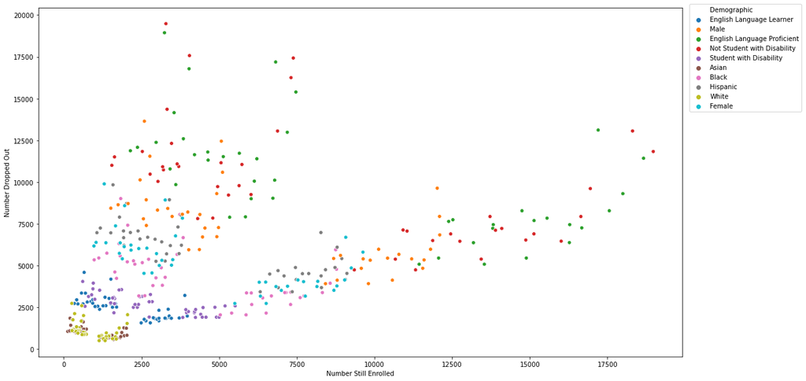

```python
plt.figure(figsize=(18,10))
sns.scatterplot(x="Number Still Enrolled",y="Number Dropped Out",data=copy_df,hue=copy_df["Demographic"])
# ax.set_xticklabels(ax.get_xticklabels(), rotation=40, ha="right")
plt.legend(loc='upper right', bbox_to_anchor=(1.19, 1.02))
```

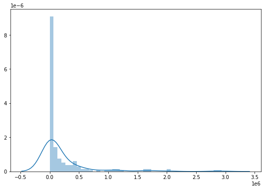

```python
plt.figure(figsize=(9,6))
sns.distplot(table)
```

[output not shown]

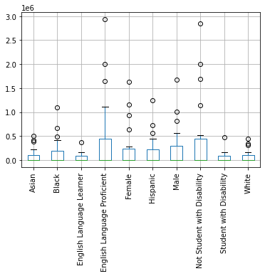

```python
table.boxplot()
plt.xticks(rotation=90)
```

```python
table.describe()
```

| Demographic | Asian | Black | English Language Learner | English Language Proficient | Female | Hispanic | Male | Not Student with Disability | Student with Disability | White |
| --- | --- | --- | --- | --- | --- | --- | --- | --- | --- | --- |
| count | 20.00000 | 2.000000e+01 | 20.000000 | 2.000000e+01 | 2.000000e+01 | 2.000000e+01 | 2.000000e+01 | 2.000000e+01 | 20.000000 | 20.00000 |
| mean | 94233.65500 | 1.689454e+05 | 54779.720000 | 4.743385e+05 | 2.691970e+05 | 1.914364e+05 | 2.600433e+05 | 4.704708e+05 | 58530.880000 | 81700.31500 |
| std | 157092.81478 | 2.886476e+05 | 90373.069361 | 8.200371e+05 | 4.604941e+05 | 3.268398e+05 | 4.445162e+05 | 8.118638e+05 | 108649.932491 | 133514.40277 |
| min | 291.00000 | 2.845000e+02 | 244.300000 | 5.277000e+02 | 5.389000e+02 | 3.456000e+02 | 5.098000e+02 | 4.818000e+02 | 41.800000 | 383.60000 |
| 25% | 1528.60000 | 1.020075e+03 | 1144.975000 | 1.015500e+03 | 1.014075e+03 | 1.033100e+03 | 9.855750e+02 | 1.035425e+03 | 1037.675000 | 1529.57500 |
| 50% | 3717.50000 | 2.926250e+03 | 2464.400000 | 3.213850e+03 | 3.254250e+03 | 2.892800e+03 | 2.998050e+03 | 3.312400e+03 | 2151.400000 | 3576.55000 |
| 75% | 103583.75000 | 1.894508e+05 | 85405.750000 | 4.509238e+05 | 2.425400e+05 | 2.221988e+05 | 2.906812e+05 | 4.482372e+05 | 88324.250000 | 98419.75000 |
| max | 502300.00000 | 1.091597e+06 | 376064.000000 | 2.932758e+06 | 1.627122e+06 | 1.247013e+06 | 1.681700e+06 | 2.842375e+06 | 466449.000000 | 446019.00000 |

```python
correlation = copy_df.corr()
correlation
```

|  | Cohort Year | Number Total Cohort | Number Total Grads | Percentage of cohort Total Grads | Number of cohort Total Grads | Percentage of cohort Total Regents | Percentage of grads Total Regents | Number of grads Total Regents | Percentage of cohort Advanced Regents | Percentage of grads Advanced Regents | Number of grads Advanced Regents | Percentage of cohort Regents w/o Advanced | Percentage of grads Regents w/o Advanced | Number of grads Regents w/o Advanced | Percentage of cohort Local | Percentage of grads Local | Number Still Enrolled | Percentage of cohort Still Enrolled | Number Dropped Out | Percentage of cohort Dropped Out |
| --- | --- | --- | --- | --- | --- | --- | --- | --- | --- | --- | --- | --- | --- | --- | --- | --- | --- | --- | --- | --- |
| Cohort Year | 1.000000 | 0.017576 | 0.103372 | 0.273136 | 0.262052 | 0.491712 | 0.610734 | 0.108798 | 0.099772 | 0.033982 | 0.315935 | 0.676096 | 0.744025 | -0.517183 | -0.719975 | -0.612753 | 0.021993 | 0.054763 | -0.312299 | -0.495498 |
| Number Total Cohort | 0.017576 | 1.000000 | 0.978621 | 0.275410 | 0.928518 | 0.237270 | 0.254839 | 0.896170 | -0.031183 | 0.008771 | 0.906683 | 0.400407 | 0.314463 | 0.621275 | -0.064968 | -0.254243 | 0.647294 | -0.126054 | 0.820904 | -0.192640 |
| Number Total Grads | 0.103372 | 0.978621 | 1.000000 | 0.415488 | 0.972033 | 0.375616 | 0.353325 | 0.939155 | 0.085005 | 0.102302 | 0.948415 | 0.509038 | 0.355700 | 0.552265 | -0.143289 | -0.352835 | 0.524744 | -0.251425 | 0.760422 | -0.274251 |
| Percentage of cohort Total Grads | 0.273136 | 0.275410 | 0.415488 | 1.000000 | 0.464393 | 0.934682 | 0.763104 | 0.542888 | 0.803787 | 0.757280 | 0.412329 | 0.717621 | 0.292857 | 0.014689 | -0.423107 | -0.762642 | -0.131607 | -0.689511 | 0.045953 | -0.681072 |
| Number of cohort Total Grads | 0.262052 | 0.928518 | 0.972033 | 0.464393 | 1.000000 | 0.487282 | 0.480533 | 0.935642 | 0.145650 | 0.153614 | 0.988614 | 0.626897 | 0.471418 | 0.341046 | -0.332200 | -0.480245 | 0.514134 | -0.233722 | 0.624042 | -0.374816 |
| Percentage of cohort Total Regents | 0.491712 | 0.237270 | 0.375616 | 0.934682 | 0.487282 | 1.000000 | 0.915406 | 0.523359 | 0.794150 | 0.756590 | 0.453892 | 0.829468 | 0.489327 | -0.226058 | -0.717545 | -0.915126 | -0.039418 | -0.501049 | -0.087786 | -0.784561 |
| Percentage of grads Total Regents | 0.610734 | 0.254839 | 0.353325 | 0.763104 | 0.480533 | 0.915406 | 1.000000 | 0.457438 | 0.608760 | 0.616404 | 0.471127 | 0.865789 | 0.721318 | -0.291342 | -0.838375 | -0.999977 | 0.142480 | -0.228303 | -0.093261 | -0.767463 |
| Number of grads Total Regents | 0.108798 | 0.896170 | 0.939155 | 0.542888 | 0.935642 | 0.523359 | 0.457438 | 1.000000 | 0.368430 | 0.391622 | 0.871878 | 0.477314 | 0.233446 | 0.431475 | -0.270133 | -0.456950 | 0.499500 | -0.276993 | 0.602181 | -0.437409 |
| Percentage of cohort Advanced Regents | 0.099772 | -0.031183 | 0.085005 | 0.803787 | 0.145650 | 0.794150 | 0.608760 | 0.368430 | 1.000000 | 0.982324 | 0.045016 | 0.319286 | -0.094860 | -0.178450 | -0.448612 | -0.608137 | -0.176324 | -0.451515 | -0.239368 | -0.671672 |
| Percentage of grads Advanced Regents | 0.033982 | 0.008771 | 0.102302 | 0.757280 | 0.153614 | 0.756590 | 0.616404 | 0.391622 | 0.982324 | 1.000000 | 0.046179 | 0.276975 | -0.100749 | -0.137351 | -0.443940 | -0.615654 | -0.073372 | -0.364662 | -0.196669 | -0.661795 |
| Number of grads Advanced Regents | 0.315935 | 0.906683 | 0.948415 | 0.412329 | 0.988614 | 0.453892 | 0.471127 | 0.871878 | 0.045016 | 0.046179 | 1.000000 | 0.666330 | 0.554571 | 0.279542 | -0.348276 | -0.470935 | 0.500195 | -0.199257 | 0.603760 | -0.337812 |
| Percentage of cohort Regents w/o Advanced | 0.676096 | 0.400407 | 0.509038 | 0.717621 | 0.626897 | 0.829468 | 0.865789 | 0.477314 | 0.319286 | 0.276975 | 0.666330 | 1.000000 | 0.850272 | -0.193937 | -0.706552 | -0.865915 | 0.109029 | -0.349803 | 0.076326 | -0.615606 |
| Percentage of grads Regents w/o Advanced | 0.744025 | 0.314463 | 0.355700 | 0.292857 | 0.471418 | 0.489327 | 0.721318 | 0.233446 | -0.094860 | -0.100749 | 0.554571 | 0.850272 | 1.000000 | -0.254787 | -0.671533 | -0.721948 | 0.256386 | 0.054559 | 0.047489 | -0.396374 |
| Number of grads Regents w/o Advanced | -0.517183 | 0.621275 | 0.552265 | 0.014689 | 0.341046 | -0.226058 | -0.291342 | 0.431475 | -0.178450 | -0.137351 | 0.279542 | -0.193937 | -0.254787 | 1.000000 | 0.605429 | 0.292318 | 0.274892 | -0.177371 | 0.829890 | 0.233737 |
| Percentage of cohort Local | -0.719975 | -0.064968 | -0.143289 | -0.423107 | -0.332200 | -0.717545 | -0.838375 | -0.270133 | -0.448612 | -0.443940 | -0.348276 | -0.706552 | -0.671533 | 0.605429 | 1.000000 | 0.838623 | -0.157984 | -0.075113 | 0.315433 | 0.667115 |
| Percentage of grads Local | -0.612753 | -0.254243 | -0.352835 | -0.762642 | -0.480245 | -0.915126 | -0.999977 | -0.456950 | -0.608137 | -0.615654 | -0.470935 | -0.865915 | -0.721948 | 0.292318 | 0.838623 | 1.000000 | -0.142742 | 0.226961 | 0.094982 | 0.768875 |
| Number Still Enrolled | 0.021993 | 0.647294 | 0.524744 | -0.131607 | 0.514134 | -0.039418 | 0.142480 | 0.499500 | -0.176324 | -0.073372 | 0.500195 | 0.109029 | 0.256386 | 0.274892 | -0.157984 | -0.142742 | 1.000000 | 0.508303 | 0.359278 | -0.265864 |
| Percentage of cohort Still Enrolled | 0.054763 | -0.126054 | -0.251425 | -0.689511 | -0.233722 | -0.501049 | -0.228303 | -0.276993 | -0.451515 | -0.364662 | -0.199257 | -0.349803 | 0.054559 | -0.177371 | -0.075113 | 0.226961 | 0.508303 | 1.000000 | -0.222906 | -0.011083 |
| Number Dropped Out | -0.312299 | 0.820904 | 0.760422 | 0.045953 | 0.624042 | -0.087786 | -0.093261 | 0.602181 | -0.239368 | -0.196669 | 0.603760 | 0.076326 | 0.047489 | 0.829890 | 0.315433 | 0.094982 | 0.359278 | -0.222906 | 1.000000 | 0.262948 |
| Percentage of cohort Dropped Out | -0.495498 | -0.192640 | -0.274251 | -0.681072 | -0.374816 | -0.784561 | -0.767463 | -0.437409 | -0.671672 | -0.661795 | -0.337812 | -0.615606 | -0.396374 | 0.233737 | 0.667115 | 0.768875 | -0.265864 | -0.011083 | 0.262948 | 1.000000 |

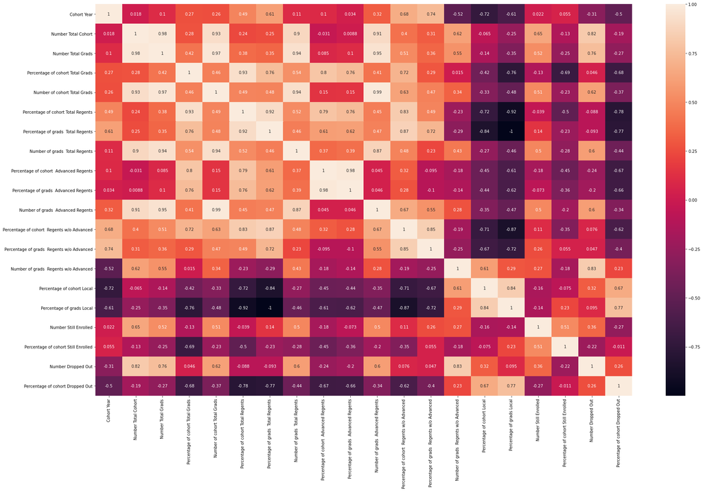

```python
plt.figure(figsize=(30,18))
sns.heatmap(correlation,annot=True)
```

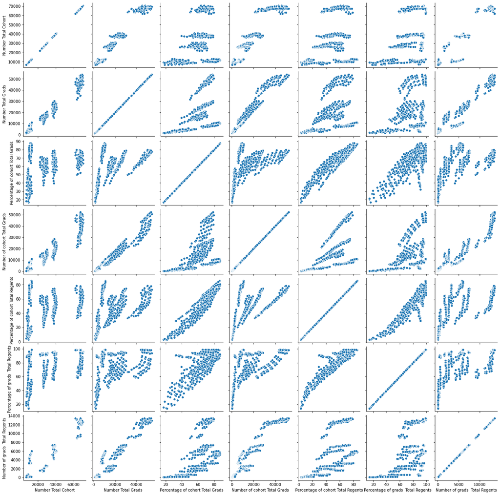

```python
plt.figure(figsize=(18,6))
g = sns.PairGrid(copy_df.iloc[:,3:10])
g.map(sns.scatterplot)
sns.set_context(font_scale=1.2)
```

## summery:

English Language Proficient & Not Student with Disability have the highest number of Dropped out of school. Asian and White has the Lowest number of Dropped out of school. number of droped out and number of enrolled are very similier to each others they do have the same distrbutions.

generally if you comapre between number of enrolled with dropped there is increase of number 2001 to 2002 about 6.155 in increase in percentage and for the dropped out there about 14.6 decrease in percentage

from 2003 till 2007 it increase and number of enrolled are catching up with dropped out and the dropped out start to increase in number again and from 2008 the number are deacreasing till 2011.

**Scatter plot**  
from the chart you can as the number of enrlloed increase the number of dropped out also increase two observation that English Language Proficient & Not Student with Disability have the highest number of droped and and enrolled and not superisingly we can see Asian and white have both lowest enrolled and droped out.

**correlation.**

- Number Total Grads & Number of cohort Total Grads & Number of grads Total Regents & Number of grads Advanced Regents have Strong correlation with Number Total Cohort.
- Number Total Grads & Number of cohort Total Grads & Number of grads Total Regents & Number of grads Advanced Regents have Strong correlation with Number Total Grads.
- and if you look you will see that number of enrolled and dropedd they have very weak correlation between them
- number of droped out have strone strong links bwtween Number Total Cohort and Number of grads w/o Advanced.